# Basics of working with geospatial data

Author

Jeet Sukumaran

**TipInstall required packages**

You will only need to do this once for each project environment (including your global project environment).

```julia
using Pkg
Pkg.add([
    "CairoMakie",
    "GeoMakie",
    "ArchGDAL",
    "Rasters",
    "RasterDataSources",
    "NaturalEarth",
])
```

## 1 Background

**Previous**:

- Basics of geospatial coordinate reference systems
- Geospatial data and coordinate reference systems

## 2 Geospatial data types: vector vs. raster

**Proficiencies**

1. Distinguish vector and raster as the two fundamental models for representing geographic information.
2. Identify which data model is appropriate for a given biological or environmental dataset.

Geographical feature data can be computationally modeled in either *vector* or *raster* form.

Vector data models the world as a collection of discrete geometrical objects (lines, polygons, and points).

Raster data models the world as a grid of cells, each associated with a value defined over its spatial support.

|  | Vector | Raster |
| --- | --- | --- |
| **Represents** | Discrete objects with defined location or boundary | Continuous surfaces sampled on a regular grid |
| **Geometry** | Points, lines, polygons | Grid of equally-sized cells (pixels) |
| **Common formats** | Shapefile (`.shp`), GeoPackage (`.gpkg`), GeoJSON (`.geojson`) | GeoTIFF (`.tif`), NetCDF (`.nc`), ASCII Grid (`.asc`) |
| **Julia tooling** | `GeoDataFrames.jl`, `Shapefile.jl`, `GeoJSON.jl` | `Rasters.jl`, `ArchGDAL.jl` |
| **Typical biological sources** | GBIF occurrences, IUCN range polygons, Natural Earth base layers, PBDB fossil localities | BIOCLIM/WorldClim climate layers, PALEOCLIM, SRTM elevation, SDM output surfaces |
| **Plot function on `GeoAxis`** | `scatter!`, `lines!`, `poly!` | `heatmap!`, `surface!` |
| **Resolution concept** | Spatial precision of coordinates | Cell size (e.g. 2.5 arcminutes, 1 km) |
| **Missing data** | Absent rows or `missing` attribute values | `NaN` cells or a defined NoData value |

**NoteMesh representations**

We might also encounter spatial or geographic features modeled as a *mesh*. In computational geometry and scientific computing, spatial data are often represented as meshes: collections of vertices and connected cells (edges, faces, or volumes) with explicit topology. Vector geometries correspond to low-dimensional meshes (e.g., points, polylines, polygonal faces), while raster data correspond to structured meshes (regular grids). Mesh representations generalize both models. However, while vector geometries and raster are classical GIS data models, “mesh” is a geometric and topological data representation used for discretizing spatial domains.

## 3 Working with vector data

**Proficiencies**

1. Distinguish the three fundamental vector geometry types: points, lines, and polygons.
2. Select the appropriate Makie plot function for each geometry type.
3. Control color, stroke, and transparency for geographic layers.

Geographic vector data are plotted with a different Makie plot function depending on their *geometry type*: **lines** (an ordered sequence of coordinate pairs), **polygons** (a closed bounded region), or **points** (a single coordinate pair) being plotted by `lines!`. `poly!`, and `scatter!`, respectively.

| Geometry type | Plot function | Typical biological source |
| --- | --- | --- |
| Point | `scatter!` | Occurrence records, fossil localities, sampling stations |
| Line / polyline | `lines!` | Coastlines, rivers, transects |
| Polygon | `poly!` | Land masks, country/state borders, biome boundaries, species ranges |

### 3.1 Plotting `NaturalEarth` geometry data

The `NaturalEarth.jl` package provides pre-cleaned Natural Earth datasets as `GeoDataFrame` objects and is the standard source for background geometry in GeoMakie workflows. The `geometry` property of the these objects provides the plotting data required.

### 3.2 Lines

Line vector datasets are plotted using `lines!`. An example of this is the dataset returned by the `GeoMakie.coastlines()` function, which is the NaturalEarth 110m scale `coastline` line vector dataset.

```julia
using CairoMakie, GeoMakie, NaturalEarth

coasts = naturalearth("coastline", 110)

fig = Figure()
ax = GeoAxis(fig[1, 1]; dest = "+proj=eqearth")
lines!(ax, coasts.geometry; color = :black, linewidth = 0.5)
fig
```

**1**

Load the NaturalEarth 110 meter scale coastline dataset.

**2**

Pass its `geometry` property to the `lines!` function as data to plot.

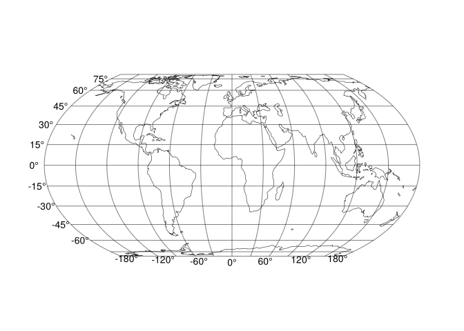

### 3.3 Polygons

`poly!` draws filled closed regions. The `color` keyword controls the fill; `strokecolor` and `strokewidth` control the border. Passing a color as an `(name, alpha)` tuple sets transparency.

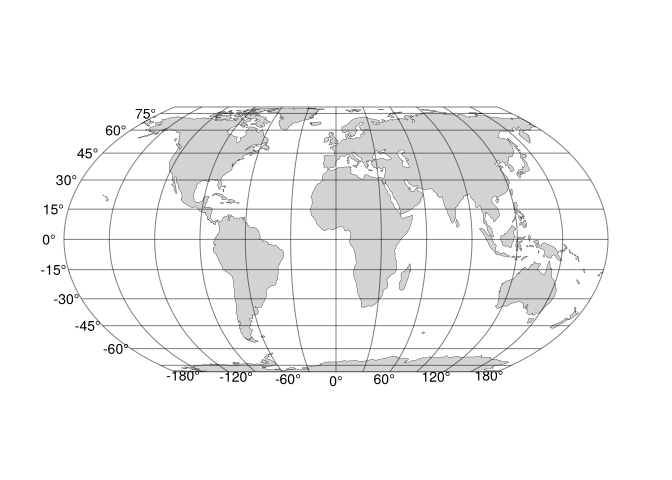

```julia
using CairoMakie, GeoMakie, NaturalEarth

land = naturalearth("land", 110)

fig = Figure()
ax = GeoAxis(fig[1, 1]; dest = "+proj=eqearth")
poly!(ax, land.geometry;
    color       = :lightgray,
    strokecolor = :black,
    strokewidth = 0.3)
fig
```

### 3.4 Points

`scatter!` draws individual coordinate pairs as markers. Here a small set of locations is specified manually; in later chapters, occurrence records from GBIF and fossil localities from PBDB will be passed in directly from data frames.

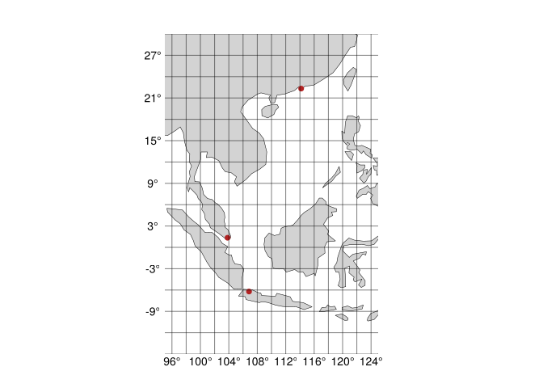

```julia
cities = [
    (114.17,  22.32),   # Hong Kong
    (103.82,   1.35),   # Singapore
    (106.84,  -6.21),   # Jakarta
]
lons = first.(cities)
lats = last.(cities)

fig = Figure()
ax = GeoAxis(fig[1, 1];
    dest   = "+proj=longlat",
    limits = (95, 125, -15, 30))
poly!(ax, land.geometry; color = :lightgray, strokewidth = 0)
lines!(ax, GeoMakie.coastlines(ax); color = :black, linewidth = 0.5)
scatter!(ax, lons, lats; color = :firebrick, markersize = 10)
fig
```

## 4 Basics of working with raster data

### 4.1 Loading raster datasets

**Proficiencies**

1. Download a raster dataset from a URL to file.
2. Load a raster dataset file to a `Rasters.Raster` object.
3. Visualize a raster dataset.

**NoteNatural Earth raster datasets**

| Dataset | Scale | File size |
| --- | --- | --- |
| [Cross-blended hypsometric tints (large)](https://www.naturalearthdata.com/http//www.naturalearthdata.com/download/10m/raster/HYP_HR_SR_OB_DR.zip) | 1:10m | 386.56 MB |
| [Cross-blended hypsometric tints (medium)](https://www.naturalearthdata.com/http//www.naturalearthdata.com/download/10m/raster/HYP_LR_SR_OB_DR.zip) | 1:10m | 228.81 MB |
| [Cross-blended hypsometric tints (small)](https://www.naturalearthdata.com/http//www.naturalearthdata.com/download/50m/raster/HYP_50M_SR_W.zip) | 1:50m | 97.46 MB |

Back to top